# Exploratory Data Analysis on Global Suicide Data

EDA on Global Suicide Data put together by Szamil from Kaggle using WHO Mortality Database.

# Prelude

PLEASE note that due to the social taboo of openly discussing suicide, the data for both suicide and suicide attempts are limited in their quality. It is likely that some countries may have under-reported or misclassified suicides, so take this article for what it is than for its factual accuracy.

# Import

#### Import libraries

```python
import pandas as pd
import numpy as np
import matplotlib
import matplotlib.pyplot as plt
import seaborn as sns
import warnings
import squarify as sq
from matplotlib.patches import Rectangle
warnings.filterwarnings("ignore")

sns.set_style('darkgrid')
plt.rcParams['figure.figsize'] = 15,15
```

```python
from jupyterthemes import jtplot
jtplot.style(figsize=(15,15))
```

#### Take in the data

```python
data = pd.read_csv('suicide.csv')
```

#### Get the basic info

```python
data.info()
```

```
<class 'pandas.core.frame.DataFrame'>
RangeIndex: 27820 entries, 0 to 27819
Data columns (total 12 columns):
country               27820 non-null object
year                  27820 non-null int64
sex                   27820 non-null object
age                   27820 non-null object
suicides_no           27820 non-null int64
population            27820 non-null int64
suicides/100k pop     27820 non-null float64
country-year          27820 non-null object
HDI for year          8364 non-null float64
 gdp_for_year ($)     27820 non-null object
gdp_per_capita ($)    27820 non-null int64
generation            27820 non-null object
dtypes: float64(2), int64(4), object(6)
memory usage: 2.5+ MB
```

#### View the first 5 rows

```python
data.head()
```

|  | country | year | sex | age | suicides_no | population | suicides/100k pop | country-year | HDI for year | gdp_for_year ($) | gdp_per_capita ($) | generation |
| --- | --- | --- | --- | --- | --- | --- | --- | --- | --- | --- | --- | --- |
| 0 | Albania | 1987 | male | 15-24 years | 21 | 312900 | 6.71 | Albania1987 | NaN | 2,156,624,900 | 796 | Generation X |
| 1 | Albania | 1987 | male | 35-54 years | 16 | 308000 | 5.19 | Albania1987 | NaN | 2,156,624,900 | 796 | Silent |
| 2 | Albania | 1987 | female | 15-24 years | 14 | 289700 | 4.83 | Albania1987 | NaN | 2,156,624,900 | 796 | Generation X |
| 3 | Albania | 1987 | male | 75+ years | 1 | 21800 | 4.59 | Albania1987 | NaN | 2,156,624,900 | 796 | G.I. Generation |
| 4 | Albania | 1987 | male | 25-34 years | 9 | 274300 | 3.28 | Albania1987 | NaN | 2,156,624,900 | 796 | Boomers |

#### Get the inferences

```python
data.describe()
```

|  | year | suicides_no | population | suicides/100k pop | HDI for year | gdp_per_capita ($) |
| --- | --- | --- | --- | --- | --- | --- |
| count | 27820.000000 | 27820.000000 | 2.782000e+04 | 27820.000000 | 8364.000000 | 27820.000000 |
| mean | 2001.258375 | 242.574407 | 1.844794e+06 | 12.816097 | 0.776601 | 16866.464414 |
| std | 8.469055 | 902.047917 | 3.911779e+06 | 18.961511 | 0.093367 | 18887.576472 |
| min | 1985.000000 | 0.000000 | 2.780000e+02 | 0.000000 | 0.483000 | 251.000000 |
| 25% | 1995.000000 | 3.000000 | 9.749850e+04 | 0.920000 | 0.713000 | 3447.000000 |
| 50% | 2002.000000 | 25.000000 | 4.301500e+05 | 5.990000 | 0.779000 | 9372.000000 |
| 75% | 2008.000000 | 131.000000 | 1.486143e+06 | 16.620000 | 0.855000 | 24874.000000 |
| max | 2016.000000 | 22338.000000 | 4.380521e+07 | 224.970000 | 0.944000 | 126352.000000 |

# Cleaning

#### View the column names

```python
data.columns
```

```
Index(['country', 'year', 'sex', 'age', 'suicides_no', 'population',
       'suicides/100k pop', 'country-year', 'HDI for year',
       ' gdp_for_year ($) ', 'gdp_per_capita ($)', 'generation'],
      dtype='object')
```

#### Replace the columns names that are hard to read

```python
column_names = ['country', 'year', 'sex', 'age', 'suicides', 'population',
       'suicidesPerK', 'countryYear', 'HDI',
       'gdp', 'gdp_pc', 'generation']
data.columns = column_names
```

#### Dropping the features that will not be covered in this analysis

```python
data = data.drop(columns=['HDI','gdp','gdp_pc'])
```

#### Typecast string-typed variables to category-type

```python
data.year = data.year.astype('category')
data.age = data.age.astype('category')
data.sex = data.sex.astype('category')
data.generation = data.generation.astype('category')
data.country = data.country.astype('category')
data.countryYear = data.countryYear.astype('category')
```

#### Mapping non-integer features to integer values to enable correlation analysis

```python
data['ageInt'] = data['age'].map({
    '5-14 years': 0,
    '15-24 years':1,
    '25-34 years':2,
    '35-54 years':3,
    '55-74 years':4,
    '75+ years': 5
})

data['sexInt'] = data['sex'].map({
    'female': 0,
    'male':1
})

data['genInt'] = data['generation'].map({
    'G.I. Generation': 0,
    'Silent':1,
    'Boomers':2,
    'Generation X':3,
    'Millenials':4,
    'Generation Z': 5
})
```

# Global Trends

### Suicides by Year

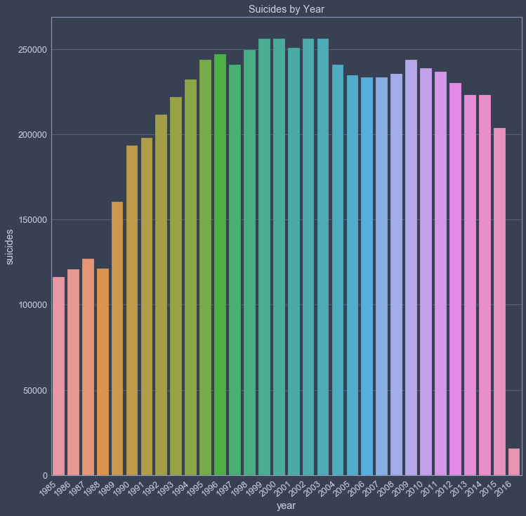

```python
suicidesByYear = sns.barplot(data = data, x = 'year', y= 'suicides', estimator=sum, ci =None)
suicidesByYear.set_title('Suicides by Year')
suicidesByYear.set_xticklabels(suicidesByYear.get_xticklabels(), rotation=40, ha="right")
plt.show()
```

Note the sudden decrease at year 2016. I am assuming the data for 2016 is incomplete, so let's remove that data

```python
data.drop(data.index[data['year'] == 2016], inplace = True)
data.year.cat = data.year.cat.remove_unused_categories()
```

### Global Change of Variables over Years

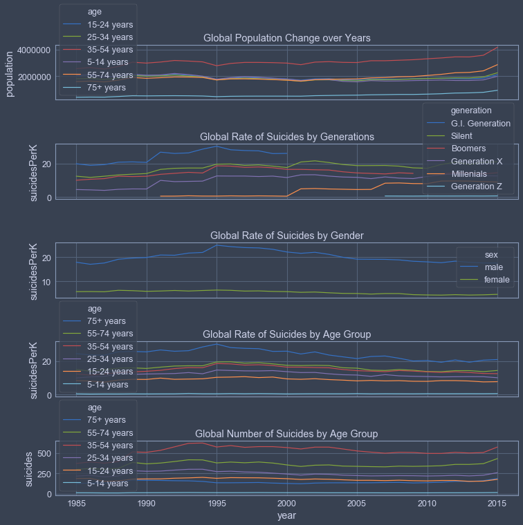

```python
fig, ax = plt.subplots(5, 1, sharex='col', sharey='row')
fig.subplots_adjust(hspace = 0.8)
sns.lineplot(data = data, x = 'year', y= 'population' , ci =None , hue='age', ax=ax[0]).set_title("Global Population Change over Years")
sns.lineplot(data = data, x = 'year', y= 'suicidesPerK' , ci =None , hue = 'generation', hue_order=['G.I. Generation', 'Silent', 'Boomers', 'Generation X', 'Millenials', 'Generation Z'], ax=ax[1]).set_title("Global Rate of Suicides by Generations")
sns.lineplot(data = data, x = 'year', y= 'suicidesPerK' , ci =None , hue = 'sex', hue_order=["male","female"], ax=ax[2]).set_title("Global Rate of Suicides by Gender")
sns.lineplot(data = data, x = 'year', y= 'suicidesPerK' , ci =None , hue = 'age', hue_order=["75+ years", "55-74 years", "35-54 years", "25-34 years", "15-24 years", "5-14 years"],ax=ax[3]).set_title("Global Rate of Suicides by Age Group")
sns.lineplot(data = data, x = 'year', y= 'suicides' , ci =None , hue = 'age', hue_order=["75+ years", "55-74 years", "35-54 years", "25-34 years", "15-24 years", "5-14 years"],ax=ax[4]).set_title("Global Number of Suicides by Age Group")
plt.show()
```

Notable Trends:

1. Looking at the rate of suicide by generation, the older generation stays consistently higher compared to the younger generations.
2. This is also true for the rate of suicide among age-groups as well. Older age groups consistently have higher rates compared to the younger groups.
3. The NUMBER of suicides has a different trend. The age-group of 35-54 years consistently tops the chart over the years, followed by 55-74 and 25-34 years. This may be due to the fact that the global population in the age of 35-54 years has the highest population throughout the years.
4. Note the gap between the males and females in their rate of suicide.

### Highest Number of Suicides by Country-Year Pair

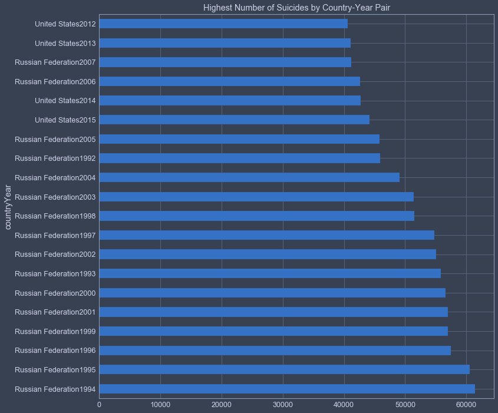

```python
topNumbers = data.groupby(['countryYear']).suicides.sum().nlargest(20).plot(kind='barh')
topNumbers.set_title("Highest Number of Suicides by Country-Year Pair")
plt.show()
```

### Highest Number of Population by Country-Year Pair

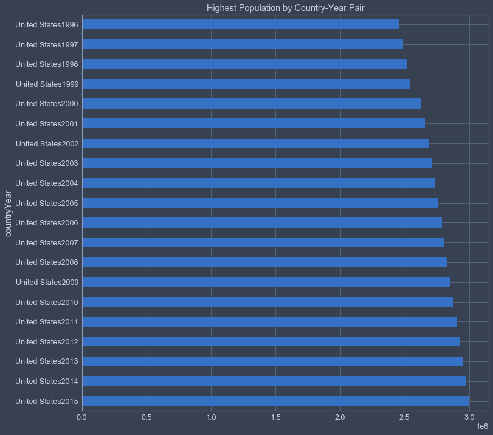

```python
topRates = data.groupby(['countryYear']).population.sum().nlargest(20).plot(kind='barh')
topRates.set_title("Highest Population by Country-Year Pair")
plt.show()
```

Note that India and China are not included in the dataset

### Number of Suicides by Year in Generations

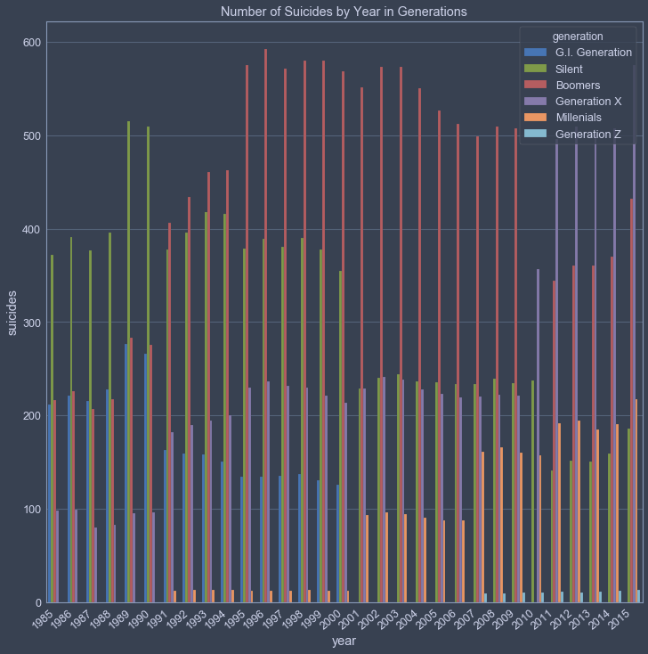

```python
suicidesByGeneration = sns.barplot(data = data, x = 'year', y= 'suicides', ci =None, hue = 'generation', hue_order=['G.I. Generation','Silent','Boomers', 'Generation X', 'Millenials', 'Generation Z'])
suicidesByGeneration.set_title('Number of Suicides by Year in Generations')
suicidesByGeneration.set_xticklabels(suicidesByGeneration.get_xticklabels(), rotation=40, ha="right")
plt.show()
```

The above graph shows the same trend noted in the "Global Change in Variables over Years" graph - the generation with its core population in the age-group of 35-54 years takes the highest number of suicides in that year.

### Rates of Suicide by Year in Generations

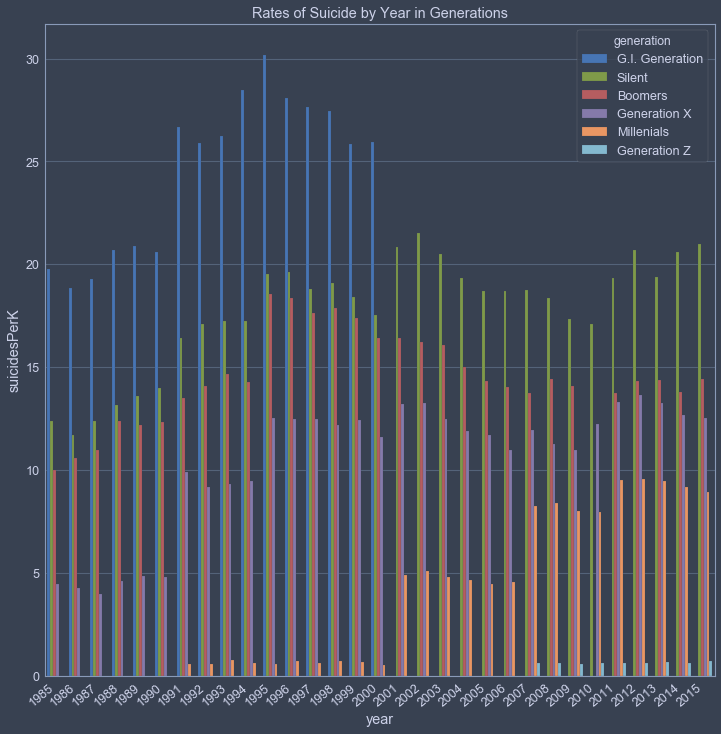

```python
suicideRatesByGeneration = sns.barplot(data = data, x = 'year', y= 'suicidesPerK', ci =None, hue = 'generation', hue_order=['G.I. Generation', 'Silent', 'Boomers', 'Generation X', 'Millenials', 'Generation Z'])
suicideRatesByGeneration.set_title('Rates of Suicide by Year in Generations')
suicideRatesByGeneration.set_xticklabels(suicideRatesByGeneration.get_xticklabels(), rotation=40, ha="right")
plt.show()
```

As noted earlier, the older a generation is, the higher its suicide rate is. Also note that in each year, the order of the rates' magnitudes is the same as the order of the generations in descending age.

# Trends in Korea

#### Subsetting the Dataframe

```python
korea = data[data['country'] == 'Republic of Korea']
```

### Change of Variables over Years in Korea

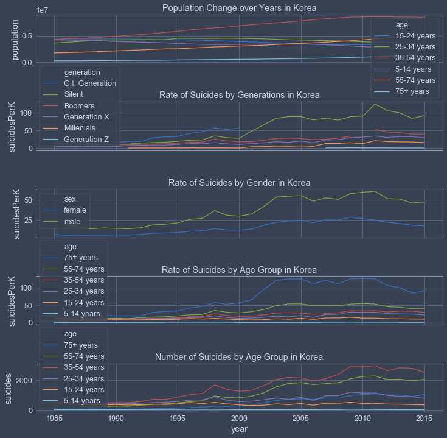

```python
fig, ax = plt.subplots(5, 1, sharex='col', sharey='row')
fig.subplots_adjust(hspace = 0.8)
sns.lineplot(data = korea, x = 'year', y= 'population' , ci =None , hue='age', ax=ax[0]).set_title("Population Change over Years in Korea")
sns.lineplot(data = korea, x = 'year', y= 'suicidesPerK' , ci =None , hue = 'generation', hue_order=['G.I. Generation', 'Silent', 'Boomers', 'Generation X', 'Millenials', 'Generation Z'], ax=ax[1]).set_title("Rate of Suicides by Generations in Korea")
sns.lineplot(data = korea, x = 'year', y= 'suicidesPerK' , ci =None , hue = 'sex', ax=ax[2]).set_title("Rate of Suicides by Gender in Korea")
sns.lineplot(data = korea, x = 'year', y= 'suicidesPerK' , ci =None , hue = 'age', hue_order=["75+ years", "55-74 years", "35-54 years", "25-34 years", "15-24 years", "5-14 years"],ax=ax[3]).set_title("Rate of Suicides by Age Group in Korea")
sns.lineplot(data = korea, x = 'year', y= 'suicides' , ci =None , hue = 'age', hue_order=["75+ years", "55-74 years", "35-54 years", "25-34 years", "15-24 years", "5-14 years"],ax=ax[4]).set_title("Number of Suicides by Age Group in Korea")
plt.show()
```

The trends in the rate of suicide in Korea stays pretty consistent with the global trends. However, there are a few notable differences:

1. The gap between the rate of suicide for 75+ years age-group and the rest is wider compared to the global trend. Inadequate care of elderly population is a known issue in Korea, and the data seems to suggest the similar.
2. The population of uppder age-groups (35 ~ 75+ years) have positive slopes where as the rest of the age-groups are slightly declining over the years. Decrease of numbers in the younger populations is also another known social issue in Korea, and the data seems to suggest the similar.

### Rate of Suicide over Years in Korea

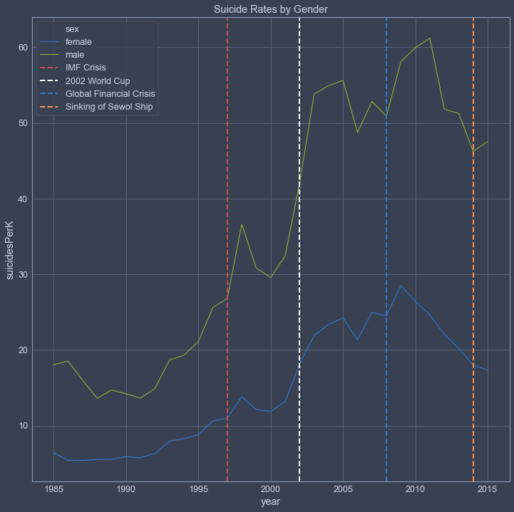

```python
suicideRatesByGenderKorea = sns.lineplot(data = korea, x = 'year',y= 'suicidesPerK', ci =None , hue = 'sex')
suicideRatesByGenderKorea.set_title('Suicide Rates by Gender')
plt.axvline(1997, 0, color='r', linestyle='--', lw=2, label="IMF Crisis")
plt.axvline(2002, 0, color='w', linestyle='--', lw=2, label="2002 World Cup")
plt.axvline(2008, 0, color='b', linestyle='--', lw=2, label="Global Financial Crisis")
plt.axvline(2014, 0, color='y', linestyle='--', lw=2, label="Sinking of Sewol Ship")
plt.legend()
plt.show()
```

Note that after a major financial crisis, the rate of suicide tends to have a notable increase.

### Suicides by Year in Korea

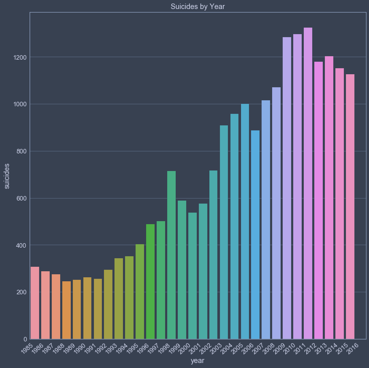

```python
suicidesByYearKorea = sns.barplot(data = korea, x = 'year', y= 'suicides' , ci =None)
suicidesByYearKorea.set_title('Suicides by Year')
suicidesByYearKorea.set_xticklabels(suicidesByYearKorea.get_xticklabels(),
                                          rotation=40, ha="right")
plt.show()
```

Note that in the earlier years (before 2002), there is a suspicion that a lot of suicides were not reported. Also, the increase in number of suicides may be due to the increase in population as well.

### Groups with the Highest Rate of Suicide in Korea

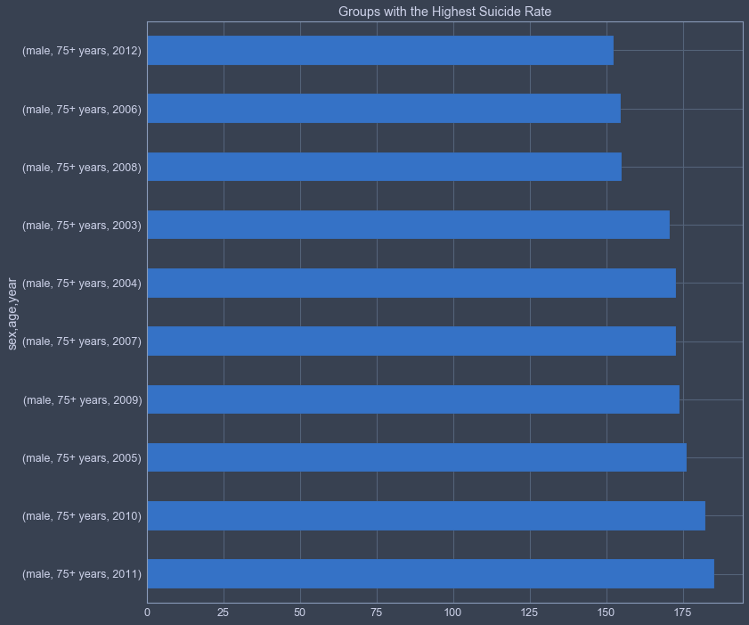

```python
highestSuicideRateKorea = korea.groupby(['sex','age','year']).suicidesPerK.sum().nlargest(10).plot(kind='barh')
highestSuicideRateKorea.set_title('Groups with the Highest Suicide Rate')
plt.show()
```

Compare the above graph with world wide

### Global Groups with the Highest Rate of Suicide

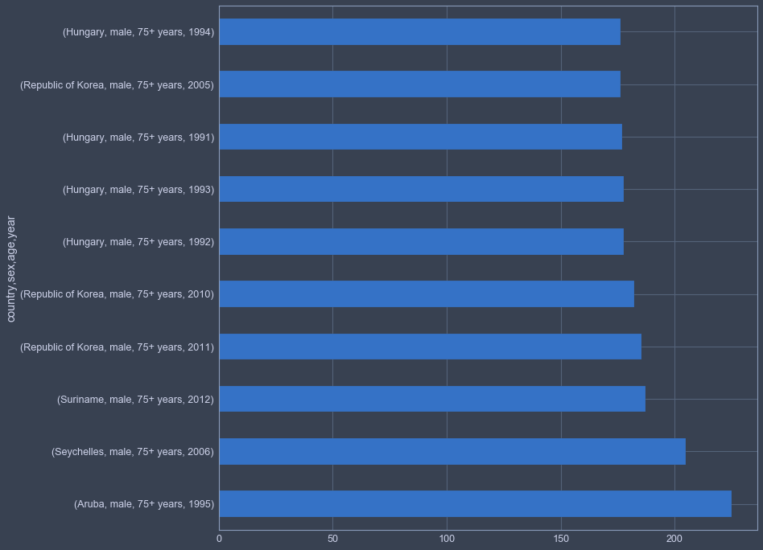

```python
data.groupby(['country','sex','age','year']).suicidesPerK.sum().nlargest(10).plot(kind='barh')
```

It is evident in the data by now that the rate among the elderly population is generally higher compared to the other groups. This may also be due to the low proportion of elderly population.

### Global Groups with Highest Number of Suicides

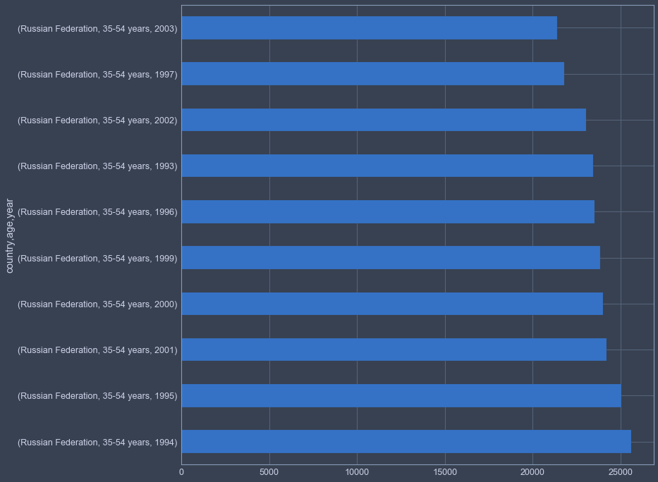

```python
data.groupby(['country','age','year']).suicides.sum().nlargest(10).plot(kind='barh')
```

### Suicide Rates by Year in Generations in Korea

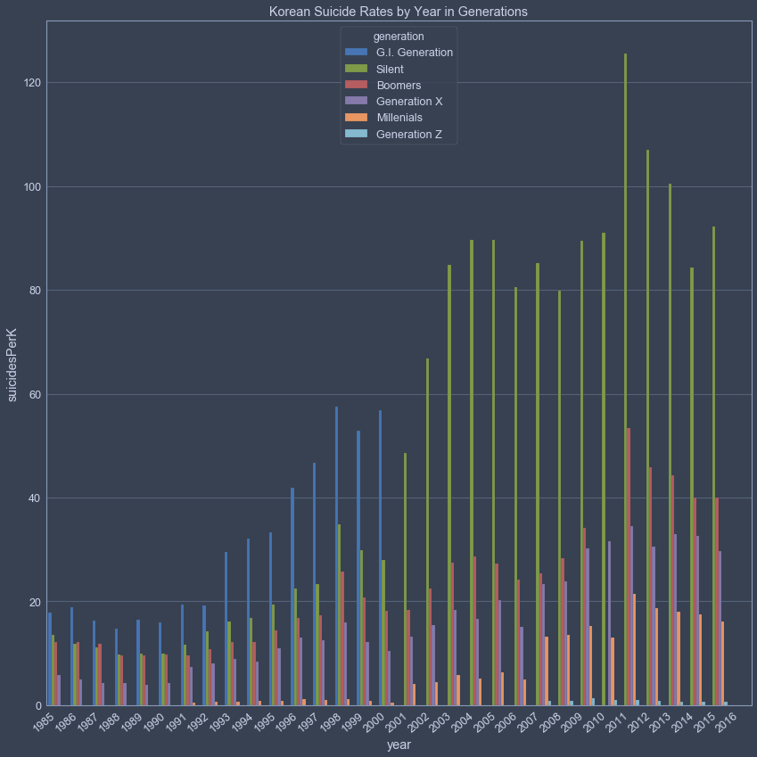

```python
suicideRatesByGenerationKorea = sns.barplot(data = korea, x = 'year', y= 'suicidesPerK' ,
                                        ci =None , hue = 'generation',
                                        hue_order=['G.I. Generation','Silent','Boomers',
                                                  'Generation X', 'Millenials', 'Generation Z'])
suicideRatesByGenerationKorea.set_title('Korean Suicide Rates by Year in Generations')
suicideRatesByGenerationKorea.set_xticklabels(suicideRatesByGenerationKorea.get_xticklabels(),
                                          rotation=40, ha="right")
plt.tight_layout()
plt.show()
```

Note the difference in the rates between the "Silent Generation" and the rest. This may be due to the low number of population in the elderly generations, but the difference in the rates is still alarming. Let's take a quick look at the population among different generations:

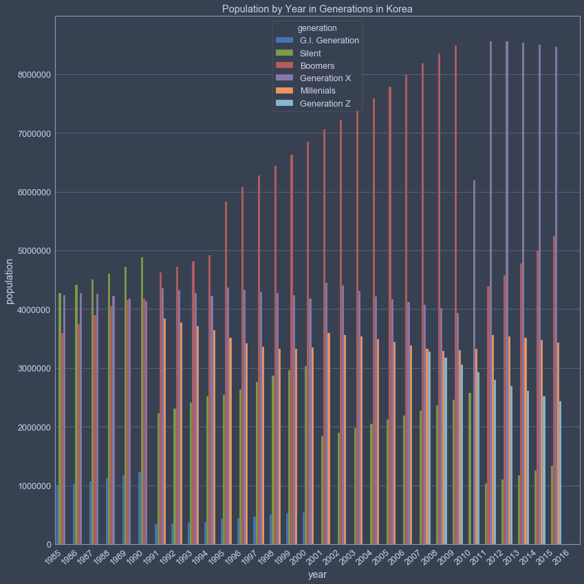

```python
populationByGenerationKorea = sns.barplot(data = korea, x = 'year', y= 'population' ,
                                        ci =None , hue = 'generation',
                                        hue_order=['G.I. Generation','Silent','Boomers',
                                                  'Generation X', 'Millenials', 'Generation Z'])
populationByGenerationKorea.set_title('Population by Year in Generations in Korea')
populationByGenerationKorea.set_xticklabels(populationByGenerationKorea.get_xticklabels(),
                                          rotation=40, ha="right")
plt.tight_layout()
plt.show()
```

Compare the rates with global trend again:

### Global Suicide Rates by Year in Generations

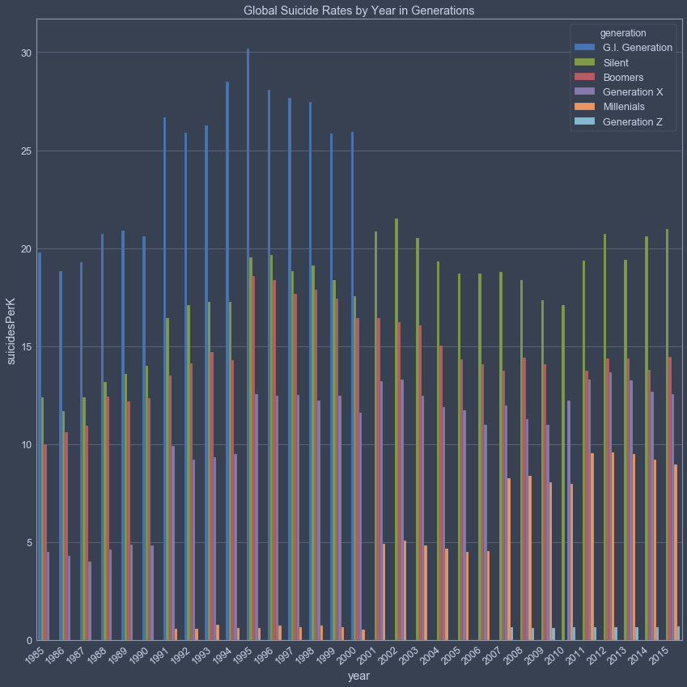

```python
suicideRatesByGenerationGlobal = sns.barplot(data = data, x = 'year', y= 'suicidesPerK' ,
                                        ci =None , hue = 'generation',
                                        hue_order=['G.I. Generation','Silent','Boomers',
                                                  'Generation X', 'Millenials', 'Generation Z'])
suicideRatesByGenerationGlobal.set_title('Global Suicide Rates by Year in Generations')
suicideRatesByGenerationGlobal.set_xticklabels(suicideRatesByGenerationGlobal.get_xticklabels(),
                                          rotation=40, ha="right")
plt.tight_layout()
plt.show()
```

Based on the above two graphs, it is evident that Korea does in fact have much higher rate of suicide among the 'Silent Generation' compared to other countries in the world (note the difference in the y-axis values between the two graphs).

### Correlation Heatmap

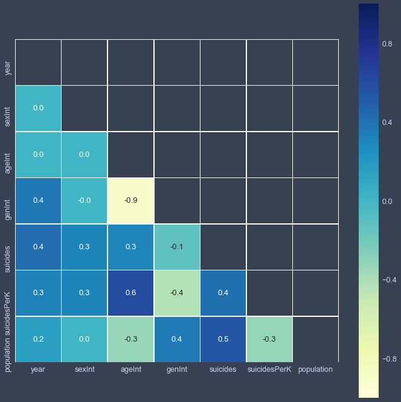

```python
koreaInt = korea[['year','sexInt','ageInt','genInt','suicides','suicidesPerK', 'population']]
koreaInt['year'] = koreaInt['year'].astype(int)
# fmt= '.1f'
# mask=koreaInt.isnull()

mask = np.zeros_like(koreaInt.corr())
mask[np.triu_indices_from(mask)] = True
koreaHeat = sns.heatmap(data=koreaInt.corr(), annot=True, mask=mask, fmt= '.01f',
                        vmin=-1, vmax=1, linewidths=.5, cmap="YlGnBu", square=True)
```

Notable correlations are:

1. Positive correlation between the population and suicides makes sense. More population a group has, the higher chance for the higher number of suicides. Population's negative correlation with the rate of suicide makes sense for the same reason.
2. Generation has negative correlation with suicide rates, which means that the younger generations tend to have lower suicide rates.
3. Age has positive correlation with suicide rates, which means that older population tend to have higher suicide rates.

# Final Remarks

Here are my final remarks:

1. The rate of suicide tends to be higher the older a generation is.
2. The number of suicide is highest in the age-group of 35-54 years, which is usually the age-group with the largest population.
3. The rate of suicide is higher in the male population as opposed to the female population.
4. In Korea, it seems that the two major financial crisis had impacts on the rate of suicide over the years.